# Differences in Language-Learning Difficulties by First Language

**Alan Golik**

CMPS 3160, Professor Saad Hassan

[Website](https://alan9011k.github.io)

# **Motivation and Data Source**

Adult language learners do not usually struggle equally with every aspect of the language they are learning; they tend to have more trouble with specific areas. A learner of English, for example, might have particular difficulty with articles, or a learner of Spanish with the subjunctive or grammatical gender. This varies from person to person, of course, as well as by native language, but there may also be broader patterns in the difficulties people have with language learning which have more global implications.

To examine these topics, I will be using two Duolingo datasets I obtained from Kaggle, at https://www.kaggle.com/datasets/aravinii/duolingo-spaced-repetition-data and https://www.kaggle.com/datasets/mesumraza/duolingo-global-language-popularity-data, both obtained originally from Duolingo itself. The first contains around thirteen million "traces" from language learners; each row is a word that one user encountered in one lesson, with data such as the user's UI language and language of study, the word's grammatical features, whether the user got it correct, and many others. Each word also comes with grammatical information, which makes it perfect; I can study the proportions of correct answers on words with certain grammatical features, which are highly language-specific. This is exactly what I want to examine! The second contains information about the most and second-most popular languages on Duolingo in each country from 2020 to 2024. This, combined with the previous dataset, can give me plenty of information on the effects of a language's difficulty for users on its global popularity.

Duolingo is a popular language-learning app that presents an opportunity to study a language casually with a much lower time commitment than traditional approaches (~30 minutes per day or less). The fact that lessons (necessarily, since accuracy is judged by a computer program) focus on translation rather than natural production of language may affect the difficulties students have, and this should be kept in mind when interpreting the data and this project's analysis of it.

This project aims to answer the following question: Can we predict the language someone is learning by using the proportions of times they get different parts of speech correct?

# **ETL & EDA — Traces dataset**

```python
import pandas as pd
import numpy
import matplotlib

traces_df = pd.read_csv("learning_traces.13m.csv")
traces_df.head()
```

|  | p_recall | timestamp | delta | user_id | learning_language | ui_language | lexeme_id | lexeme_string | history_seen | history_correct | session_seen | session_correct |
| --- | --- | --- | --- | --- | --- | --- | --- | --- | --- | --- | --- | --- |
| 0 | 1.0 | 1362076081 | 27649635 | u:FO | de | en | 76390c1350a8dac31186187e2fe1e178 | lernt/lernen<vblex><pri><p3><sg> | 6 | 4 | 2 | 2 |
| 1 | 0.5 | 1362076081 | 27649635 | u:FO | de | en | 7dfd7086f3671685e2cf1c1da72796d7 | die/die<det><def><f><sg><nom> | 4 | 4 | 2 | 1 |
| 2 | 1.0 | 1362076081 | 27649635 | u:FO | de | en | 35a54c25a2cda8127343f6a82e6f6b7d | mann/mann<n><m><sg><nom> | 5 | 4 | 1 | 1 |
| 3 | 0.5 | 1362076081 | 27649635 | u:FO | de | en | 0cf63ffe3dda158bc3dbd55682b355ae | frau/frau<n><f><sg><nom> | 6 | 5 | 2 | 1 |
| 4 | 1.0 | 1362076081 | 27649635 | u:FO | de | en | 84920990d78044db53c1b012f5bf9ab5 | das/das<det><def><nt><sg><nom> | 4 | 4 | 1 | 1 |

Let's begin with a quick breakdown of the variables:

- **learning_language** — The language the user is learning.
- **ui_language** — The language to which the user's interface is set, likely their native language.
- **lexeme_string** — The "lexeme", or word, that the user encountered. The string begins with the particular form of the word found in the lesson (e.g. "ran"), then the "lemma" (basic) form of the word (e.g. "run"), and various grammatical information as brief tags enclosed in angle brackets. The part of speech is given first. A noun is marked <n>, a lexical verb (one that carries meaning) is marked <vblex>, a determiner (such as an article) is marked <det>, etc. Nouns, adjectives and determiners come with information about gender (masculine, feminine or neuter), number (singular or plural) and case (nominative, accusative, dative or genitive, each marking a different grammatical role in the sentence) when the language has these. (All five languages other than English have grammatical gender on nouns, adjectives and determiners, only German marks case, and all six languages mark number on nouns, with the five other than English also marking it on determiners and adjectives.) Verbs have information about tense, voice, mood, person and number. In general, all words have tags for any grammatical feature that might be relevant.
- **session_seen** — The number of times the given lexeme/form of the word appeared in the given lesson/practice
- **session_correct** — The number of times the user got the word correct
- **history_seen** and **history_correct** — The same as the two above, but across all previous lessons/practices rather than the current one
- **p_recall** — The proportion of times that the word was correctly recalled in this session: equal to session_correct divided by session_seen
- **user_id** — An anonymized ID number for the user
- **timestamp** — The UNIX timestamp of the lesson
- **delta** — The number of seconds since the previous lesson where this word came up
- **lexeme_id** — The system ID for the given lexeme

Each row already corresponds to one observation, with each variable comprising a column and the whole table comprising an observational unit. Therefore, the data appears to already be tidy (with the exception that multiple dtypes are present in the same dataset, but this seems unavoidable), and no melting is necessary. However, there is still some processing to do. The timestamp and delta columns, for instance, are not remotely related to our purposes with the data. Also, since the lexeme_string column also uniquely identifies the word/lexeme under observation, the lexeme_id column is redundant (and less easily interpretable). Also, we don't need the "session_seen", "session_correct" or "p_recall" variables if "history_seen" and "history_correct" are more comprehensive. Therefore, we can safely delete all of these.

```python
# Drops the lexeme_id, timestamp, delta, p_recall, session_seen and session_correct columns from the dataframe
traces_df.drop(columns = ["timestamp", "delta", "lexeme_id", "p_recall", "session_seen", "session_correct"], inplace = True)
traces_df
```

|  | user_id | learning_language | ui_language | lexeme_string | history_seen | history_correct |
| --- | --- | --- | --- | --- | --- | --- |
| 0 | u:FO | de | en | lernt/lernen<vblex><pri><p3><sg> | 6 | 4 |
| 1 | u:FO | de | en | die/die<det><def><f><sg><nom> | 4 | 4 |
| 2 | u:FO | de | en | mann/mann<n><m><sg><nom> | 5 | 4 |
| 3 | u:FO | de | en | frau/frau<n><f><sg><nom> | 6 | 5 |
| 4 | u:FO | de | en | das/das<det><def><nt><sg><nom> | 4 | 4 |
| ... | ... | ... | ... | ... | ... | ... |
| 12854221 | u:i5D8 | en | it | the/the<det><def><sp> | 6 | 4 |
| 12854222 | u:i5D8 | en | it | eat/eat<vblex><pres> | 4 | 4 |
| 12854223 | u:i5D8 | en | it | bread/bread<n><sg> | 4 | 4 |
| 12854224 | u:i5D8 | en | it | drink/drink<vblex><pres> | 3 | 2 |
| 12854225 | u:i5D8 | en | it | water/water<n><sg> | 5 | 3 |

12854226 rows × 6 columns

To begin, let's check the dtypes to make sure everything's in order.

```python
traces_df.dtypes
```

|  | 0 |
| --- | --- |
| user_id | object |
| learning_language | object |
| ui_language | object |
| lexeme_string | object |
| history_seen | int64 |
| history_correct | int64 |

**dtype:** object

Everything is as expected! The user IDs, language names and lexeme strings are, in fact, strings (and therefore objects), while history_seen and history_correct are integers. There are no NaNs or empty spaces.

Next, let's see how many users are in this database, to make sure we have a substantial sample size of different users we can compare and that any model we build will yield useful results:

```python
# Returns number of unique user IDs
traces_df["user_id"].nunique()
```

```
115222
```

115,222 certainly does not seem like a bad sample size! Let's see which languages these users speak and are learning:

```python
# Returns array of languages to which users' UIs are set
traces_df["ui_language"].unique()
```

```
array(['en', 'pt', 'es', 'it'], dtype=object)
```

```python
traces_df["learning_language"].unique()
```

```
array(['de', 'es', 'pt', 'en', 'fr', 'it'], dtype=object)
```

Our users have their UIs set to English, Portuguese, Spanish, or Italian, and are learning those languages plus German and French. This is a small group of closely related languages — English and German are both Germanic, the other four are all Romance, all are Indo-European, and they have had plenty of contact with each other over many centuries. All of these languages share many grammatical features, so the difficulties learners have may not be as varied as we would like to see. Nonetheless, a study on these six still promises to be interesting.

We should note that the ui_language column contains the language to which the user has set their interface — the language from which they are learning their target language, which is stored in learning_language. For most users, this will likely be their native language or one they use regularly in everyday life, but some users may be challenging themselves to learn a target language from another target language, to improve their command of the UI language as well. This is a common enough practice that it may affect a large part of our dataset, and we should keep it in mind when analyzing and interpreting the data.

Let's take a look at the number of UI users and learners of each language.

```python
traces_df.groupby(["ui_language"]).user_id.nunique()
```

| ui_language | user_id |
| --- | --- |
| en | 71662 |
| es | 31735 |
| it | 3436 |
| pt | 8637 |

**dtype:** int64

```python
traces_df.groupby(["learning_language"]).user_id.nunique()
```

| learning_language | user_id |
| --- | --- |
| de | 14383 |
| en | 43805 |
| es | 31155 |
| fr | 19947 |
| it | 6498 |
| pt | 2709 |

**dtype:** int64

The numbers seem fairly asymmetrical. The most common UI language is English by far, with Spanish also far ahead of Italian and Portuguese. English and Spanish are the most popular languages to learn, with French, German, Italian and Portuguese in tow (respectively).

Let's take a look at this data all at once in a pivot table and a bar graph.

```python
traces_pivot_table = traces_df.pivot_table(index = "ui_language",
                                     columns = "learning_language",
                                     values = "user_id",
                                     aggfunc = "nunique")
traces_pivot_table
```

| learning_language ui_language | de | en | es | fr | it | pt |
| --- | --- | --- | --- | --- | --- | --- |
| en | 14383.0 | NaN | 31155.0 | 19947.0 | 6498.0 | 2709.0 |
| es | NaN | 31735.0 | NaN | NaN | NaN | NaN |
| it | NaN | 3436.0 | NaN | NaN | NaN | NaN |
| pt | NaN | 8637.0 | NaN | NaN | NaN | NaN |

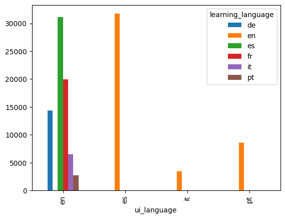

```python
traces_pivot_table.plot.bar()
```

As we can see, this dataset has a pretty clear limitation: it only records users who speak or are learning English. I could predict whether an English-learner speaks Spanish, Portuguese or Italian based on the proportions of different types of English words they get right. However, I suspect these three languages are too similar grammatically for there to be any meaningful differences. As such, I will try to predict the language an English-speaker is learning (German, French, Spanish, Portuguese or Italian) based on their difficulties with different parts of speech. There is a slightly greater variety of languages here, and French and German especially are different enough from the rest that it should make a difference. As such, we can remove any rows where the UI language isn't English.

```python
traces_df = traces_df[traces_df["ui_language"] == "en"]
traces_df
```

|  | user_id | learning_language | ui_language | lexeme_string | history_seen | history_correct |
| --- | --- | --- | --- | --- | --- | --- |
| 0 | u:FO | de | en | lernt/lernen<vblex><pri><p3><sg> | 6 | 4 |
| 1 | u:FO | de | en | die/die<det><def><f><sg><nom> | 4 | 4 |
| 2 | u:FO | de | en | mann/mann<n><m><sg><nom> | 5 | 4 |
| 3 | u:FO | de | en | frau/frau<n><f><sg><nom> | 6 | 5 |
| 4 | u:FO | de | en | das/das<det><def><nt><sg><nom> | 4 | 4 |
| ... | ... | ... | ... | ... | ... | ... |
| 12854214 | u:gqqz | es | en | vacaciones/vacaciones<n><f><pl> | 6 | 5 |
| 12854215 | u:gqqz | es | en | corres/correr<vblex><pri><p2><sg> | 6 | 5 |
| 12854216 | u:gqqz | es | en | mañana/mañana<adv> | 8 | 6 |
| 12854217 | u:gqqz | es | en | son/ser<vbser><pri><p3><pl> | 47 | 40 |
| 12854218 | u:gqqz | es | en | corto/corto<adj><m><sg> | 5 | 4 |

7839435 rows × 6 columns

Finally, let's take a look at the proportions of words of different parts of speech that users got right. The first thing to do is make sure the same word appearing more than once for the same user doesn't skew the results. Since history_seen and history_correct record the TOTAL number of times a user has seen a word or gotten it correct, if we find a duplicate word for a given user, we just need to keep the one with higher values of these variables — the more comprehensive one (this version of the word was encountered by the user later and therefore its history_seen and history_correct values are more recent).

```python
# I group the dataframe by user ID and lexeme string (grouping the rows with the same word and user),
# take the maximum of their history_seen and history_correct values, and add these columns onto traces_df.
# Then, I use them to calculate the proprtion of correct answers overall for a given word, drop the four now-redundant columns,
# and drop the duplicate rows.

total_history = traces_df.groupby(by = ["user_id", "lexeme_string"])[["history_seen", "history_correct"]].agg(func = "max")
traces_df = traces_df.join(other = total_history, on = ["user_id", "lexeme_string"], lsuffix = "_old")
traces_df["prop_correct"] = traces_df["history_correct"]/traces_df["history_seen"]
traces_df.drop(columns = ["history_seen_old", "history_correct_old", "history_seen", "history_correct"], inplace = True)
traces_df.drop_duplicates(inplace = True)
traces_df
```

|  | user_id | learning_language | ui_language | lexeme_string | prop_correct |
| --- | --- | --- | --- | --- | --- |
| 0 | u:FO | de | en | lernt/lernen<vblex><pri><p3><sg> | 0.812500 |
| 1 | u:FO | de | en | die/die<det><def><f><sg><nom> | 0.800000 |
| 2 | u:FO | de | en | mann/mann<n><m><sg><nom> | 0.875000 |
| 3 | u:FO | de | en | frau/frau<n><f><sg><nom> | 0.769231 |
| 4 | u:FO | de | en | das/das<det><def><nt><sg><nom> | 0.818182 |
| ... | ... | ... | ... | ... | ... |
| 12854166 | u:iWSo | it | en | <*sf>/volere<vbmod><pri><*pers><*numb> | 1.000000 |
| 12854169 | u:iZE_ | de | en | wein/wein<n><m><sg><acc> | 1.000000 |
| 12854188 | u:iZE_ | de | en | mögen/mögen<vbmod><pri><p1><pl> | 1.000000 |
| 12854200 | u:iZE_ | de | en | tisch/tisch<n><m><sg><acc> | 1.000000 |
| 12854212 | u:gqqz | es | en | grandes/grande<adj><mf><pl> | 1.000000 |

3795013 rows × 5 columns

Next, we need to reduce the lexeme_string column to its part of speech. This will be the word's first tag — the first occurrence of the character '<' to the first occurrence of '>'. We can accomplish this with a basic regex.

```python
import re
pattern = re.compile(r"<.*?>")

traces_df["lexeme_string"] = traces_df["lexeme_string"].apply(lambda x: pattern.search(x).group(0))
traces_df
```

|  | user_id | learning_language | ui_language | lexeme_string | prop_correct |
| --- | --- | --- | --- | --- | --- |
| 0 | u:FO | de | en | <vblex> | 0.812500 |
| 1 | u:FO | de | en | <det> | 0.800000 |
| 2 | u:FO | de | en | <n> | 0.875000 |
| 3 | u:FO | de | en | <n> | 0.769231 |
| 4 | u:FO | de | en | <det> | 0.818182 |
| ... | ... | ... | ... | ... | ... |
| 12854166 | u:iWSo | it | en | <*sf> | 1.000000 |
| 12854169 | u:iZE_ | de | en | <n> | 1.000000 |
| 12854188 | u:iZE_ | de | en | <vbmod> | 1.000000 |
| 12854200 | u:iZE_ | de | en | <n> | 1.000000 |
| 12854212 | u:gqqz | es | en | <adj> | 1.000000 |

3795013 rows × 5 columns

Let's see what parts of speech we're working with!

```python
traces_df["lexeme_string"].unique()
```

```
array(['<vblex>', '<det>', '<n>', '<pr>', '<prn>', '<vbser>', '<cnjcoo>',
       '<adv>', '<adj>', '<*sf>', '<cnjadv>', '<cnjsub>', '<vbmod>',
       '<@common_phrases:a_demain>', '<@common_phrases:il_y_a>',
       '<@common_phrases:comment_ca_va>', '<@common_phrases:a_plus_tard>',
       '<@common_phrases:ca_va_bien>', '<ij>', '<vbhaver>', '<preadv>',
       '<@cnj:des_que>', '<@cnj:alors_que>', '<@adv:s_il_te_plait>',
       '<@cnj:du_fait_que>', '<@cnj:depuis_que>', '<@ij:au_revoir>',
       '<@common_phrases:de_rien>', '<np>', '<@ij:merci_beaucoup>',
       '<@ij:auf_wiedersehen>', '<@ij:buenas_noches>',
       '<@ij:buenos_dias>', '<@itg:est_ce_que>', '<rel>', '<num>',
       '<@adv:a_part>', '<@pr:un_peu_de>', '<@adv:por_favor>',
       '<@ij:bis_bald>', '<@common_phrases:a_bientot>',
       '<@common_phrases:a_plus>', '<@adv:s_il_vous_plait>',
       '<@pr:pres_de>', '<@adv:por_supuesto>', '<@pr:plus_de>', '<pprep>',
       '<@cnj:parce_que>', '<@cnj:tandis_que>', '<@adv:a_peu_pres>',
       '<@neg:plus_de>', '<@adv:tout_a_fait>', '<@neg:pas_du_tout>',
       '<vaux>', '<predet>', '<@adv:peut_etre>', '<@cnj:pendant_que>',
       '<@itg:que_est_ce_que>', '<@pr:a_travers>', '<@adv:en_general>',
       '<@adv:au_dela>', '<@adv:en_fait>', '<@cnj:pour_que>',
       '<@pr:au_dela_de>', '<@pr:afin_de>', '<@pr:autant_de>',
       '<@cnj:bien_que>', '<@pr:a_cause_de>', '<@pr:a_cote_de>',
       '<@cnj:apres_que>', '<@prn:n_importe_quoi>', '<@adv:au_moins>',
       '<@adv:a_posteriori>', '<@adv:a_priori>', '<@cnj:avant_que>',
       '<ord>', '<@cnj:autant_que>'], dtype=object)
```

As we can see, there are plenty of hyperspecific tags for specific phrases. We can simply ignore these, since they will clearly skew the results — obviously, if you're learning the phrase "buenas noches", you're learning Spanish.

```python
mask = lambda x: x in ['<vblex>', '<det>', '<n>', '<pr>', '<prn>', '<vbser>', '<cnjcoo>', '<adv>', '<adj>', '<*sf>', '<cnjadv>', '<cnjsub>', '<vbmod>', '<ij>', '<vbhaver>', '<preadv>', '<np>', '<rel>', '<num>', '<pprep>', '<vaux>', '<predet>', '<ord>']
traces_df = traces_df[traces_df["lexeme_string"].apply(mask)]
traces_df
```

|  | user_id | learning_language | ui_language | lexeme_string | prop_correct |
| --- | --- | --- | --- | --- | --- |
| 0 | u:FO | de | en | <vblex> | 0.812500 |
| 1 | u:FO | de | en | <det> | 0.800000 |
| 2 | u:FO | de | en | <n> | 0.875000 |
| 3 | u:FO | de | en | <n> | 0.769231 |
| 4 | u:FO | de | en | <det> | 0.818182 |
| ... | ... | ... | ... | ... | ... |
| 12854166 | u:iWSo | it | en | <*sf> | 1.000000 |
| 12854169 | u:iZE_ | de | en | <n> | 1.000000 |
| 12854188 | u:iZE_ | de | en | <vbmod> | 1.000000 |
| 12854200 | u:iZE_ | de | en | <n> | 1.000000 |
| 12854212 | u:gqqz | es | en | <adj> | 1.000000 |

3760114 rows × 5 columns

```python
user_traces_df = traces_df.groupby(by = ["user_id", "lexeme_string"])["prop_correct"].mean()
user_traces_df = user_traces_df.unstack()
user_traces_df = user_traces_df.fillna(0)
user_traces_df
```

| lexeme_string user_id | <*sf> | <adj> | <adv> | <cnjadv> | <cnjcoo> | <cnjsub> | <det> | <ij> | <n> | <np> | ... | <pr> | <preadv> | <predet> | <prn> | <rel> | <vaux> | <vbhaver> | <vblex> | <vbmod> | <vbser> |
| --- | --- | --- | --- | --- | --- | --- | --- | --- | --- | --- | --- | --- | --- | --- | --- | --- | --- | --- | --- | --- | --- |
| u:--N | 0.000000 | 0.000000 | 0.500000 | 0.000000 | 0.000000 | 0.0 | 0.838971 | 0.000000 | 0.898639 | 0.0 | ... | 0.937500 | 0.0000 | 0.0 | 1.000000 | 0.0 | 0.0 | 0.000000 | 0.930556 | 0.666667 | 0.500000 |
| u:--U | 0.000000 | 0.904762 | 0.000000 | 0.000000 | 0.000000 | 0.0 | 0.000000 | 0.000000 | 0.000000 | 0.0 | ... | 0.000000 | 0.0000 | 0.0 | 0.000000 | 0.0 | 0.0 | 0.000000 | 0.000000 | 0.000000 | 0.000000 |
| u:-3I | 0.000000 | 0.000000 | 0.000000 | 0.000000 | 0.884615 | 0.0 | 0.000000 | 0.000000 | 0.000000 | 0.0 | ... | 0.000000 | 0.0000 | 0.0 | 0.833333 | 0.0 | 0.0 | 0.000000 | 0.908874 | 0.000000 | 0.000000 |
| u:-3n | 0.000000 | 0.879743 | 0.940103 | 0.000000 | 0.865672 | 0.0 | 0.880188 | 1.000000 | 0.900266 | 0.0 | ... | 0.861246 | 0.9375 | 0.0 | 0.879618 | 1.0 | 0.0 | 0.000000 | 0.887337 | 0.900000 | 0.932127 |
| u:-4V | 0.000000 | 1.000000 | 0.937500 | 0.000000 | 0.900000 | 0.0 | 0.913184 | 0.000000 | 0.928837 | 0.0 | ... | 0.981647 | 0.0000 | 0.0 | 0.879246 | 0.9 | 0.0 | 0.954751 | 0.944264 | 1.000000 | 0.975595 |
| ... | ... | ... | ... | ... | ... | ... | ... | ... | ... | ... | ... | ... | ... | ... | ... | ... | ... | ... | ... | ... | ... |
| u:zz3 | 0.911073 | 0.944385 | 0.714286 | 0.000000 | 0.000000 | 0.0 | 0.933782 | 0.000000 | 0.948002 | 0.0 | ... | 0.881720 | 0.0000 | 0.0 | 0.904192 | 0.0 | 1.0 | 0.000000 | 0.920147 | 0.000000 | 0.962963 |
| u:zz8 | 0.822222 | 0.930808 | 1.000000 | 0.857143 | 1.000000 | 0.0 | 0.878452 | 1.000000 | 0.959687 | 0.0 | ... | 0.813952 | 0.0000 | 0.0 | 0.918224 | 1.0 | 0.0 | 0.000000 | 0.899326 | 1.000000 | 0.852737 |
| u:zzI | 0.000000 | 0.000000 | 0.000000 | 0.000000 | 0.000000 | 0.0 | 0.833333 | 0.000000 | 0.875000 | 0.0 | ... | 0.000000 | 0.0000 | 0.0 | 0.000000 | 0.0 | 0.0 | 0.000000 | 0.833333 | 0.000000 | 0.000000 |
| u:zzU | 0.000000 | 0.000000 | 0.000000 | 0.000000 | 0.000000 | 0.0 | 0.754167 | 0.000000 | 0.754167 | 0.0 | ... | 0.000000 | 0.0000 | 0.0 | 0.666667 | 0.0 | 0.0 | 0.000000 | 0.000000 | 0.000000 | 0.666667 |
| u:zzv | 0.000000 | 0.000000 | 0.000000 | 0.000000 | 0.000000 | 0.0 | 0.940306 | 0.816667 | 0.886720 | 0.0 | ... | 0.000000 | 0.0000 | 0.0 | 0.835519 | 0.0 | 0.0 | 0.000000 | 0.897177 | 0.000000 | 0.789294 |

71655 rows × 23 columns

We have a dataframe containing every user and their proportions of correct answers on every part of speech! Now let's add in their target language.

```python
target_langs = traces_df[["user_id", "learning_language"]].drop_duplicates()
target_langs.set_index("user_id", inplace = True)
user_traces_df = user_traces_df.join(other = target_langs, on = "user_id")
user_traces_df
```

| user_id | <*sf> | <adj> | <adv> | <cnjadv> | <cnjcoo> | <cnjsub> | <det> | <ij> | <n> | <np> | ... | <preadv> | <predet> | <prn> | <rel> | <vaux> | <vbhaver> | <vblex> | <vbmod> | <vbser> | learning_language |
| --- | --- | --- | --- | --- | --- | --- | --- | --- | --- | --- | --- | --- | --- | --- | --- | --- | --- | --- | --- | --- | --- |
| u:--N | 0.000000 | 0.000000 | 0.500000 | 0.000000 | 0.000000 | 0.0 | 0.838971 | 0.000000 | 0.898639 | 0.0 | ... | 0.0000 | 0.0 | 1.000000 | 0.0 | 0.0 | 0.000000 | 0.930556 | 0.666667 | 0.500000 | de |
| u:--U | 0.000000 | 0.904762 | 0.000000 | 0.000000 | 0.000000 | 0.0 | 0.000000 | 0.000000 | 0.000000 | 0.0 | ... | 0.0000 | 0.0 | 0.000000 | 0.0 | 0.0 | 0.000000 | 0.000000 | 0.000000 | 0.000000 | de |
| u:-3I | 0.000000 | 0.000000 | 0.000000 | 0.000000 | 0.884615 | 0.0 | 0.000000 | 0.000000 | 0.000000 | 0.0 | ... | 0.0000 | 0.0 | 0.833333 | 0.0 | 0.0 | 0.000000 | 0.908874 | 0.000000 | 0.000000 | fr |
| u:-3n | 0.000000 | 0.879743 | 0.940103 | 0.000000 | 0.865672 | 0.0 | 0.880188 | 1.000000 | 0.900266 | 0.0 | ... | 0.9375 | 0.0 | 0.879618 | 1.0 | 0.0 | 0.000000 | 0.887337 | 0.900000 | 0.932127 | es |
| u:-4V | 0.000000 | 1.000000 | 0.937500 | 0.000000 | 0.900000 | 0.0 | 0.913184 | 0.000000 | 0.928837 | 0.0 | ... | 0.0000 | 0.0 | 0.879246 | 0.9 | 0.0 | 0.954751 | 0.944264 | 1.000000 | 0.975595 | de |
| ... | ... | ... | ... | ... | ... | ... | ... | ... | ... | ... | ... | ... | ... | ... | ... | ... | ... | ... | ... | ... | ... |
| u:zz3 | 0.911073 | 0.944385 | 0.714286 | 0.000000 | 0.000000 | 0.0 | 0.933782 | 0.000000 | 0.948002 | 0.0 | ... | 0.0000 | 0.0 | 0.904192 | 0.0 | 1.0 | 0.000000 | 0.920147 | 0.000000 | 0.962963 | de |
| u:zz8 | 0.822222 | 0.930808 | 1.000000 | 0.857143 | 1.000000 | 0.0 | 0.878452 | 1.000000 | 0.959687 | 0.0 | ... | 0.0000 | 0.0 | 0.918224 | 1.0 | 0.0 | 0.000000 | 0.899326 | 1.000000 | 0.852737 | fr |
| u:zzI | 0.000000 | 0.000000 | 0.000000 | 0.000000 | 0.000000 | 0.0 | 0.833333 | 0.000000 | 0.875000 | 0.0 | ... | 0.0000 | 0.0 | 0.000000 | 0.0 | 0.0 | 0.000000 | 0.833333 | 0.000000 | 0.000000 | de |
| u:zzU | 0.000000 | 0.000000 | 0.000000 | 0.000000 | 0.000000 | 0.0 | 0.754167 | 0.000000 | 0.754167 | 0.0 | ... | 0.0000 | 0.0 | 0.666667 | 0.0 | 0.0 | 0.000000 | 0.000000 | 0.000000 | 0.666667 | pt |
| u:zzv | 0.000000 | 0.000000 | 0.000000 | 0.000000 | 0.000000 | 0.0 | 0.940306 | 0.816667 | 0.886720 | 0.0 | ... | 0.0000 | 0.0 | 0.835519 | 0.0 | 0.0 | 0.000000 | 0.897177 | 0.000000 | 0.789294 | it |

74684 rows × 24 columns

# **ETL & EDA — Country rankings dataset**

```python
ranking_df = pd.read_excel("Duolingo_Language_Ranking_Cleaned.xlsx")
ranking_df.head()
```

|  | Country | Year | Popularity_Ranking | Language |
| --- | --- | --- | --- | --- |
| 0 | Afghanistan | 2020 | 1 | English |
| 1 | Afghanistan | 2021 | 1 | English |
| 2 | Afghanistan | 2022 | 1 | German |
| 3 | Afghanistan | 2023 | 1 | English |
| 4 | Afghanistan | 2024 | 1 | English |

Each row in this dataset records a country's name, the year in question, the language in question, and its popularity as a language of study on Duolingo in that country in that year (only the two most popular are recorded — 1 or 2). This follows textbook tidy data principles already — each row is an observation and each column is a variable. Now let's look at things from the perspective of the languages!

```python
pop_table = ranking_df.groupby(["Year", "Popularity_Ranking", "Language"]).Country.nunique()
pop_table
```

| Year | Popularity_Ranking | Language | Country |
| --- | --- | --- | --- |
| 2020 | 1 | English | 119 |
|  |  | French | 23 |
|  |  | German | 8 |
|  |  | Irish | 1 |
|  |  | Japanese | 3 |
| ... | ... | ... | ... |
| 2024 | 2 | Russian | 4 |
|  |  | Spanish | 37 |
|  |  | Swahili | 1 |
|  |  | Swedish | 1 |
|  |  | Turkish | 1 |

128 rows × 1 columns

**dtype:** int64

This table paints a picture of how popular each language was every year (counting the number of times each language appears in position 1 or 2, respectively, each year). Let's graph this to see it a little more clearly. First, we'll need to reformat the data as a pivot table.

```python
ranking_pivot_table = ranking_df.pivot_table(index = ["Year", "Popularity_Ranking"],
                                     columns = "Language",
                                     values = "Country",
                                     aggfunc = "nunique")
ranking_pivot_table
```

| Year | Language Popularity_Ranking | Arabic | Chinese | Danish | English | Finnish | French | German | Guarani | Hebrew | Hindi | ... | Italian | Japanese | Korean | Norwegian | Portuguese | Russian | Spanish | Swahili | Swedish | Turkish |
| --- | --- | --- | --- | --- | --- | --- | --- | --- | --- | --- | --- | --- | --- | --- | --- | --- | --- | --- | --- | --- | --- | --- |
| 2020 | 1 | NaN | NaN | NaN | 119.0 | NaN | 23.0 | 8.0 | NaN | NaN | NaN | ... | NaN | 3.0 | 4.0 | NaN | NaN | NaN | 34.0 | NaN | 1.0 | NaN |
|  | 2 | NaN | 3.0 | 2.0 | 8.0 | NaN | 71.0 | 14.0 | NaN | NaN | 1.0 | ... | 4.0 | 6.0 | 3.0 | 1.0 | 4.0 | 3.0 | 70.0 | 1.0 | 1.0 | 1.0 |
| 2021 | 1 | NaN | NaN | NaN | 119.0 | NaN | 24.0 | 7.0 | NaN | NaN | NaN | ... | 2.0 | 5.0 | 2.0 | NaN | NaN | NaN | 31.0 | 1.0 | 1.0 | NaN |
|  | 2 | NaN | 4.0 | 2.0 | 10.0 | 1.0 | 66.0 | 14.0 | 1.0 | NaN | 1.0 | ... | 3.0 | 9.0 | 8.0 | 1.0 | 4.0 | 5.0 | 59.0 | NaN | NaN | 5.0 |
| 2022 | 1 | NaN | NaN | NaN | 119.0 | NaN | 22.0 | 8.0 | NaN | NaN | NaN | ... | 2.0 | 2.0 | 4.0 | NaN | NaN | NaN | 34.0 | 1.0 | 1.0 | NaN |
|  | 2 | 1.0 | 6.0 | 1.0 | 11.0 | 1.0 | 74.0 | 16.0 | NaN | 1.0 | 1.0 | ... | 3.0 | 12.0 | 7.0 | 1.0 | 4.0 | 5.0 | 47.0 | 1.0 | NaN | NaN |
| 2023 | 1 | NaN | 1.0 | NaN | 121.0 | NaN | 22.0 | 8.0 | NaN | NaN | NaN | ... | 1.0 | 5.0 | 1.0 | NaN | NaN | NaN | 34.0 | NaN | NaN | NaN |
|  | 2 | 2.0 | 4.0 | NaN | 15.0 | 1.0 | 73.0 | 18.0 | NaN | 1.0 | 1.0 | ... | 4.0 | 10.0 | 7.0 | 1.0 | 5.0 | 5.0 | 42.0 | 2.0 | 1.0 | NaN |
| 2024 | 1 | NaN | NaN | NaN | 134.0 | NaN | 16.0 | 5.0 | NaN | NaN | NaN | ... | 1.0 | 4.0 | NaN | NaN | NaN | NaN | 33.0 | NaN | NaN | NaN |
|  | 2 | 2.0 | 5.0 | NaN | 19.0 | 1.0 | 73.0 | 20.0 | NaN | 1.0 | 1.0 | ... | 2.0 | 11.0 | 4.0 | 1.0 | 8.0 | 4.0 | 37.0 | 1.0 | 1.0 | 1.0 |

10 rows × 21 columns

Let's replace all the NaNs with zeroes, and make everything an integer for the sake of making our table easier to read.

```python
ranking_pivot_table.fillna(0, inplace = True)
ranking_pivot_table = ranking_pivot_table.astype(int)
ranking_pivot_table
```

| Year | Language Popularity_Ranking | Arabic | Chinese | Danish | English | Finnish | French | German | Guarani | Hebrew | Hindi | ... | Italian | Japanese | Korean | Norwegian | Portuguese | Russian | Spanish | Swahili | Swedish | Turkish |
| --- | --- | --- | --- | --- | --- | --- | --- | --- | --- | --- | --- | --- | --- | --- | --- | --- | --- | --- | --- | --- | --- | --- |
| 2020 | 1 | 0 | 0 | 0 | 119 | 0 | 23 | 8 | 0 | 0 | 0 | ... | 0 | 3 | 4 | 0 | 0 | 0 | 34 | 0 | 1 | 0 |
|  | 2 | 0 | 3 | 2 | 8 | 0 | 71 | 14 | 0 | 0 | 1 | ... | 4 | 6 | 3 | 1 | 4 | 3 | 70 | 1 | 1 | 1 |
| 2021 | 1 | 0 | 0 | 0 | 119 | 0 | 24 | 7 | 0 | 0 | 0 | ... | 2 | 5 | 2 | 0 | 0 | 0 | 31 | 1 | 1 | 0 |
|  | 2 | 0 | 4 | 2 | 10 | 1 | 66 | 14 | 1 | 0 | 1 | ... | 3 | 9 | 8 | 1 | 4 | 5 | 59 | 0 | 0 | 5 |
| 2022 | 1 | 0 | 0 | 0 | 119 | 0 | 22 | 8 | 0 | 0 | 0 | ... | 2 | 2 | 4 | 0 | 0 | 0 | 34 | 1 | 1 | 0 |
|  | 2 | 1 | 6 | 1 | 11 | 1 | 74 | 16 | 0 | 1 | 1 | ... | 3 | 12 | 7 | 1 | 4 | 5 | 47 | 1 | 0 | 0 |
| 2023 | 1 | 0 | 1 | 0 | 121 | 0 | 22 | 8 | 0 | 0 | 0 | ... | 1 | 5 | 1 | 0 | 0 | 0 | 34 | 0 | 0 | 0 |
|  | 2 | 2 | 4 | 0 | 15 | 1 | 73 | 18 | 0 | 1 | 1 | ... | 4 | 10 | 7 | 1 | 5 | 5 | 42 | 2 | 1 | 0 |
| 2024 | 1 | 0 | 0 | 0 | 134 | 0 | 16 | 5 | 0 | 0 | 0 | ... | 1 | 4 | 0 | 0 | 0 | 0 | 33 | 0 | 0 | 0 |
|  | 2 | 2 | 5 | 0 | 19 | 1 | 73 | 20 | 0 | 1 | 1 | ... | 2 | 11 | 4 | 1 | 8 | 4 | 37 | 1 | 1 | 1 |

10 rows × 21 columns

Perfect! Now we can plot our bar graph.

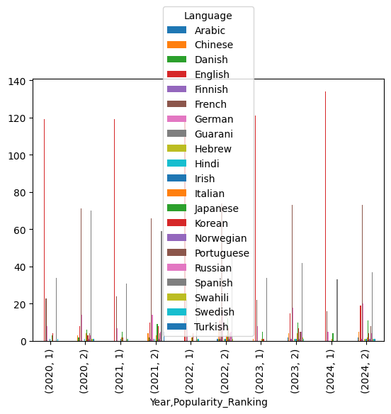

```python
ranking_pivot_table.plot.bar()
```

It's a bit difficult to see everything, but English is the clear frontrunner across all years, with French and Spanish following behind. German seems to not be too far behind those as well. Overall, there are clearly differences in popularity, and I'd like to study how those are related to a language's "difficulty level" for English speakers across many users.

From this point forward, I'm going to aggregate the popularity rankings (1 or 2) into one score; a language will get 1 "point" for being the most popular in a country in a given year, and 1/2 "point" for being the second most popular. I'll do this by adding together the "1" and "2" rows within each year (multiplying the "2" row by 0.5 first) and passing that into a new DataFrame object using a comprehension. I'm also fixing the indices, since they revert to 0–4, by adding 2020 to each one.

```python
agg_ranking_df = pd.DataFrame((ranking_pivot_table.loc[(year, 1)] + 0.5*ranking_pivot_table.loc[(year, 2)]) for year in range(2020, 2025))
agg_ranking_df.rename({idx : idx + 2020 for idx in range(5)}, inplace = True)
agg_ranking_df
```

| Language | Arabic | Chinese | Danish | English | Finnish | French | German | Guarani | Hebrew | Hindi | ... | Italian | Japanese | Korean | Norwegian | Portuguese | Russian | Spanish | Swahili | Swedish | Turkish |
| --- | --- | --- | --- | --- | --- | --- | --- | --- | --- | --- | --- | --- | --- | --- | --- | --- | --- | --- | --- | --- | --- |
| 2020 | 0.0 | 1.5 | 1.0 | 123.0 | 0.0 | 58.5 | 15.0 | 0.0 | 0.0 | 0.5 | ... | 2.0 | 6.0 | 5.5 | 0.5 | 2.0 | 1.5 | 69.0 | 0.5 | 1.5 | 0.5 |
| 2021 | 0.0 | 2.0 | 1.0 | 124.0 | 0.5 | 57.0 | 14.0 | 0.5 | 0.0 | 0.5 | ... | 3.5 | 9.5 | 6.0 | 0.5 | 2.0 | 2.5 | 60.5 | 1.0 | 1.0 | 2.5 |
| 2022 | 0.5 | 3.0 | 0.5 | 124.5 | 0.5 | 59.0 | 16.0 | 0.0 | 0.5 | 0.5 | ... | 3.5 | 8.0 | 7.5 | 0.5 | 2.0 | 2.5 | 57.5 | 1.5 | 1.0 | 0.0 |
| 2023 | 1.0 | 3.0 | 0.0 | 128.5 | 0.5 | 58.5 | 17.0 | 0.0 | 0.5 | 0.5 | ... | 3.0 | 10.0 | 4.5 | 0.5 | 2.5 | 2.5 | 55.0 | 1.0 | 0.5 | 0.0 |
| 2024 | 1.0 | 2.5 | 0.0 | 143.5 | 0.5 | 52.5 | 15.0 | 0.0 | 0.5 | 0.5 | ... | 2.0 | 9.5 | 2.0 | 0.5 | 4.0 | 2.0 | 51.5 | 0.5 | 0.5 | 0.5 |

5 rows × 21 columns

Let's graph this one as a bar graph as well!

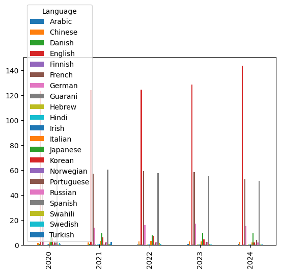

```python
agg_ranking_df.plot.bar()
```

There seems to be a noticeable upward trend in the popularity of English over time, as well as a slight downward trend in its two closest runners-up, French and Spanish.

Let's remove those three and look at the trends among less popular languages, since they make it difficult to see the rest.

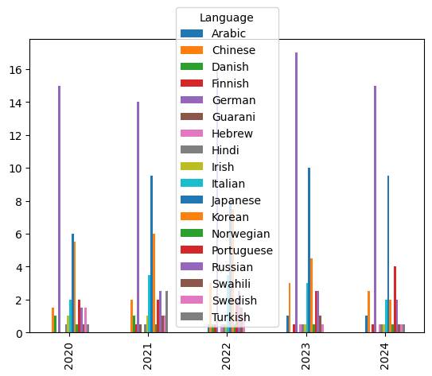

```python
no_enfres = agg_ranking_df.drop(columns = ["English", "French", "Spanish"])
no_enfres.plot.bar()
```

# **Modeling**

As I mentioned earlier, I'd like to predict the language someone is learning by using the proportions of times they get different parts of speech correct. To answer this, let's build a k-nearest-neighbors classification model. The independent variables (input to the distance function) will be the aggregate proportions of correct answers for different parts of speech for a given user (observation), and the dependent variable (output) would be the language that user is learning. Obviously, given our data, this model will assume the user's first language is English.

Let's import Scikit-Learn and built a k-nearest-neighbors classifier! Our data is all on the same scale (proportions from 0 to 1), so no need to rescale/normalize.

```python
import sklearn

X = user_traces_df.drop(columns = "learning_language")
y = user_traces_df["learning_language"]

X_train, X_test, y_train, y_test = sklearn.model_selection.train_test_split(X, y, test_size=0.5)

KNC = sklearn.neighbors.KNeighborsClassifier(n_neighbors=100)
KNC.fit(X_train, y_train)

y_predict = KNC.predict(X_test)

sklearn.metrics.accuracy_score(y_test, y_predict)
```

```
0.711504472176102
```

# **Conclusion**

Overall, we see that proportions of correct answers on different parts of speech is not the best predictor of what language someone is learning, at least among the five closely-related European languages we studied. An avenue for further research/modeling might be looking at features like grammatical gender, case and tense directly, rather than simply parts of speech. This tells us that among these five languages, there are certainly some differences in difficulties among English-speakers between different parts of speech, but they aren't that great a predictor of what language a given English-speaker is learning.